# NEON ForestAGB — Allometry of Tree Growth: Initial Size vs Growth Rate

plant_scaling_data project

2026-05-02

# 1 Overview

This document focuses specifically on the **allometric relationship between initial tree size and growth rate** using the NEON ForestAGB longitudinal dataset. The central question is: *does growth rate scale with body size, and if so, with what exponent?*

- **Absolute diameter increment** $\Delta D$ (cm yr⁻¹) — raw size increase
- **Absolute AGB increment** $\Delta M$ (kg yr⁻¹) — biomass accumulation
- **Relative growth rate** RGR = $\frac{\ln D_2 - \ln D_1}{\Delta t}$ (yr⁻¹) — proportional growth

Three theoretical predictions from metabolic scaling theory (MST) provide reference benchmarks:

| Metric | MST prediction | Biological interpretation |
| --- | --- | --- |
| $\Delta D \propto D^{\,\beta}$ | $\beta \approx 1/3$ | Pipe model + WBE network |
| $\Delta M \propto M^{\,\gamma}$ | $\gamma \approx 3/4$ | Metabolic rate scales as $M^{3/4}$ |
| RGR$_D \propto D^{\,\delta}$ | $\delta \approx -2/3$ | Declining relative growth with size |

> **AGB caveat:** Biomass is model-derived from DBH (Chojnacky et al. 2014). AGB increments are algebraically dependent on DBH increments and should not be treated as independent measurements. All AGB allometry here reflects the allometric equations used, not directly measured carbon accumulation.

# 2 Data summary

```r
kable(data.frame(
  Metric = c(
    "Total annual growth intervals",
    "Intervals with positive \u0394D (used for log-log fit)",
    "Intervals with positive \u0394AGB (used for log-log fit)",
    "Unique individuals",
    "Sites",
    "DBH range at interval start (1st\u201399th pct)",
    "AGB range at interval start (1st\u201399th pct)"
  ),
  Value = c(
    format(nrow(annual), big.mark=","),
    format(nrow(pos_dbh), big.mark=","),
    format(nrow(pos_agb), big.mark=","),
    format(length(unique(annual$individualID)), big.mark=","),
    length(neon_sites),
    paste0(round(quantile(pos_dbh$DBH_start, 0.01),1), "\u2013",
           round(quantile(pos_dbh$DBH_start, 0.99),1), " cm"),
    paste0(round(quantile(pos_agb$AGB_start, 0.01, na.rm=TRUE),1), "\u2013",
           round(quantile(pos_agb$AGB_start, 0.99, na.rm=TRUE),1), " kg")
  ),
  stringsAsFactors = FALSE
), caption = "Data scope for growth allometry analysis")
```

Data scope for growth allometry analysis

| Metric | Value |
| --- | --- |
| Total annual growth intervals | 75,657 |
| Intervals with positive ΔD (used for log-log fit) | 51,176 |
| Intervals with positive ΔAGB (used for log-log fit) | 43,848 |
| Unique individuals | 27,716 |
| Sites | 23 |
| DBH range at interval start (1st–99th pct) | 1.1–64.3 cm |
| AGB range at interval start (1st–99th pct) | 0.1–2990.6 kg |

> **Note on negative increments:** 14,683 intervals (19.4%) have negative DBH increment, reflecting measurement error, bark sloughing, or height-of-measurement changes — not genuine shrinkage. Log-log regressions are fit on **positive-increment intervals only**.

# 3 Absolute diameter increment ($\Delta D$) vs initial DBH

## 3.1 Scatter + power-law fit

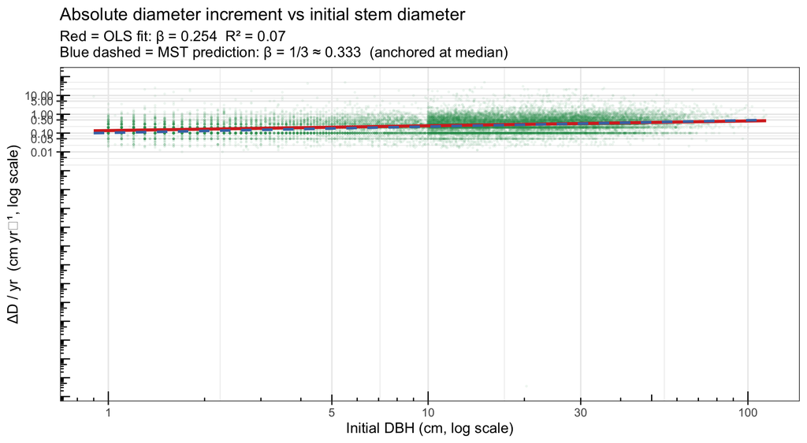

```r
set.seed(42)
sub <- pos_dbh |> sample_n(min(25000, n()))

m_dbh <- lm(log(DBH_inc_cm_yr) ~ log(DBH_start), data = sub)
beta_dbh <- round(coef(m_dbh)[2], 3)
r2_dbh   <- round(summary(m_dbh)$r.squared, 3)

# MST reference line: delta_D ~ D^(1/3), anchored at median
med_d <- median(sub$DBH_start)
med_inc <- median(sub$DBH_inc_cm_yr)
alpha_mst <- med_inc / med_d^(1/3)

dbh_seq <- seq(min(sub$DBH_start), max(sub$DBH_start), length.out = 200)
ref_mst <- data.frame(
  DBH_start     = dbh_seq,
  DBH_inc_cm_yr = alpha_mst * dbh_seq^(1/3)
)

ggplot(sub, aes(x = DBH_start, y = DBH_inc_cm_yr)) +
  geom_point(alpha = 0.06, size = 0.5, color = "#1a9850") +
  geom_smooth(method = "lm", formula = y ~ x,    # OLS on log-log space
              color = "#d73027", linewidth = 1.3, se = TRUE) +
  geom_line(data = ref_mst, aes(x = DBH_start, y = DBH_inc_cm_yr),
            color = "#4575b4", linewidth = 1.1, linetype = "dashed") +
  scale_x_log10(labels = comma, breaks = c(1, 5, 10, 30, 100)) +
  scale_y_log10(labels = comma, breaks = c(0.01, 0.05, 0.1, 0.5, 1, 5, 10)) +
  annotation_logticks() +
  labs(
    x = "Initial DBH (cm, log scale)",
    y = "\u0394D / yr  (cm yr\u207b\u00b9, log scale)",
    title = "Absolute diameter increment vs initial stem diameter",
    subtitle = paste0(
      "Red = OLS fit: \u03b2 = ", beta_dbh, "  R\u00b2 = ", r2_dbh,
      "\nBlue dashed = MST prediction: \u03b2 = 1/3 \u2248 0.333  (anchored at median)"
    )
  )
```

## 3.2 Binned means (log-spaced DBH bins)

Binning reduces scatter and shows the central tendency more clearly.

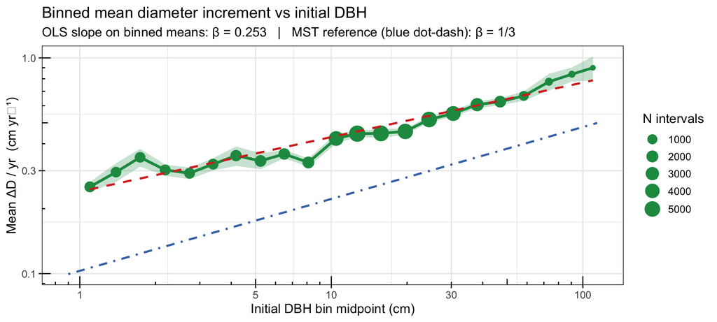

```r
bin_dbh <- pos_dbh |>
  mutate(DBH_bin = cut(log10(DBH_start),
                       breaks = seq(log10(1), log10(200), length.out = 25),
                       include.lowest = TRUE)) |>
  filter(!is.na(DBH_bin)) |>
  group_by(DBH_bin) |>
  summarise(
    n            = n(),
    DBH_mid      = 10^mean(log10(DBH_start)),
    mean_inc     = mean(DBH_inc_cm_yr),
    median_inc   = median(DBH_inc_cm_yr),
    se_inc       = sd(DBH_inc_cm_yr) / sqrt(n()),
    .groups      = "drop"
  ) |>
  filter(n >= 10)

m_bin <- lm(log(mean_inc) ~ log(DBH_mid), data = bin_dbh)
beta_bin <- round(coef(m_bin)[2], 3)

ggplot(bin_dbh, aes(x = DBH_mid, y = mean_inc)) +
  geom_ribbon(aes(ymin = pmax(mean_inc - se_inc, 1e-4),
                  ymax = mean_inc + se_inc),
              fill = "#1a9850", alpha = 0.25) +
  geom_line(color = "#1a9850", linewidth = 1.3) +
  geom_point(aes(size = n), color = "#1a9850") +
  geom_smooth(method = "lm", formula = y ~ x,
              color = "#d73027", linewidth = 1, linetype = "dashed", se = FALSE) +
  geom_line(data = ref_mst, aes(x = DBH_start, y = DBH_inc_cm_yr),
            color = "#4575b4", linewidth = 1, linetype = "dotdash",
            inherit.aes = FALSE) +
  scale_x_log10(labels = comma, breaks = c(1, 5, 10, 30, 100)) +
  scale_y_log10(labels = comma) +
  annotation_logticks() +
  scale_size_continuous(range = c(2, 7), name = "N intervals") +
  labs(
    x = "Initial DBH bin midpoint (cm)",
    y = "Mean \u0394D / yr  (cm yr\u207b\u00b9)",
    title = "Binned mean diameter increment vs initial DBH",
    subtitle = paste0(
      "OLS slope on binned means: \u03b2 = ", beta_bin,
      "   |   MST reference (blue dot-dash): \u03b2 = 1/3"
    )
  )
```

## 3.3 Distribution of $\Delta D$ within DBH size classes

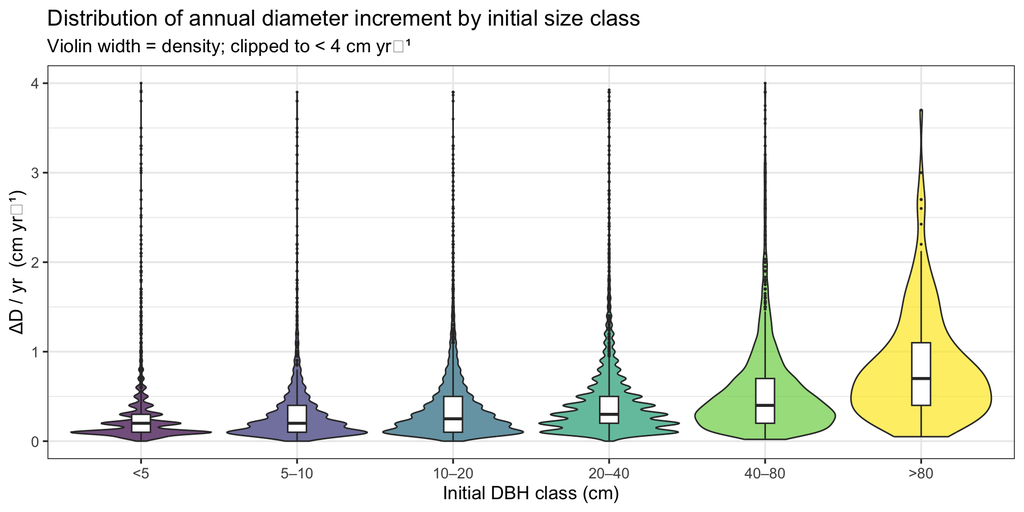

```r
pos_dbh |>
  filter(DBH_inc_cm_yr < 4) |>
  mutate(DBH_class = cut(DBH_start,
                         breaks = c(0, 5, 10, 20, 40, 80, Inf),
                         labels = c("<5","5\u201310","10\u201320",
                                    "20\u201340","40\u201380",">80"),
                         right  = FALSE)) |>
  filter(!is.na(DBH_class)) |>
  ggplot(aes(x = DBH_class, y = DBH_inc_cm_yr, fill = DBH_class)) +
  geom_violin(trim = TRUE, scale = "width", alpha = 0.7, show.legend = FALSE) +
  geom_boxplot(width = 0.12, outlier.size = 0.3, fill = "white", show.legend = FALSE) +
  scale_fill_viridis_d(option = "D") +
  labs(
    x = "Initial DBH class (cm)",
    y = "\u0394D / yr  (cm yr\u207b\u00b9)",
    title = "Distribution of annual diameter increment by initial size class",
    subtitle = "Violin width = density; clipped to < 4 cm yr\u207b\u00b9"
  )
```

# 4 Absolute AGB increment ($\Delta M$) vs initial AGB

> AGB is estimated from DBH via Chojnacky et al. (2014). $\Delta M$ values are algebraically derived from $\Delta D$ — they are not independent measurements.

## 4.1 Scatter + power-law fit

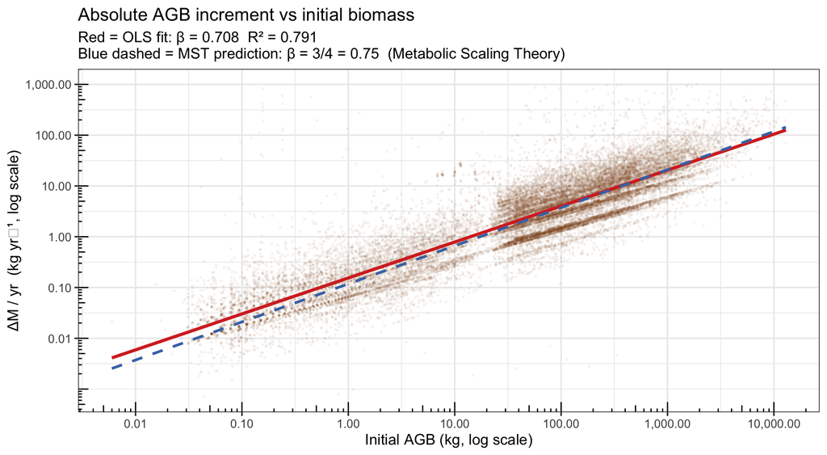

```r
set.seed(42)
sub_agb <- pos_agb |>
  filter(AGB_start > 0, AGB_start < 20000,
         AGB_inc_kg_yr < 1000) |>
  sample_n(min(25000, n()))

m_agb <- lm(log(AGB_inc_kg_yr) ~ log(AGB_start), data = sub_agb)
beta_agb <- round(coef(m_agb)[2], 3)
r2_agb   <- round(summary(m_agb)$r.squared, 3)

# MST reference: delta_M ~ M^(3/4), anchored at median
med_M    <- median(sub_agb$AGB_start)
med_dM   <- median(sub_agb$AGB_inc_kg_yr)
alpha_mst_agb <- med_dM / med_M^(3/4)
agb_seq  <- seq(min(sub_agb$AGB_start), max(sub_agb$AGB_start), length.out = 200)
ref_mst_agb <- data.frame(
  AGB_start     = agb_seq,
  AGB_inc_kg_yr = alpha_mst_agb * agb_seq^(3/4)
)

ggplot(sub_agb, aes(x = AGB_start, y = AGB_inc_kg_yr)) +
  geom_point(alpha = 0.05, size = 0.5, color = "#8c510a") +
  geom_smooth(method = "lm", formula = y ~ x,
              color = "#d73027", linewidth = 1.3, se = TRUE) +
  geom_line(data = ref_mst_agb,
            aes(x = AGB_start, y = AGB_inc_kg_yr),
            color = "#4575b4", linewidth = 1.1, linetype = "dashed",
            inherit.aes = FALSE) +
  scale_x_log10(labels = comma,
                breaks = c(0.01, 0.1, 1, 10, 100, 1000, 10000)) +
  scale_y_log10(labels = comma,
                breaks = c(0.01, 0.1, 1, 10, 100, 1000)) +
  annotation_logticks() +
  labs(
    x = "Initial AGB (kg, log scale)",
    y = "\u0394M / yr  (kg yr\u207b\u00b9, log scale)",
    title = "Absolute AGB increment vs initial biomass",
    subtitle = paste0(
      "Red = OLS fit: \u03b2 = ", beta_agb, "  R\u00b2 = ", r2_agb,
      "\nBlue dashed = MST prediction: \u03b2 = 3/4 = 0.75  (Metabolic Scaling Theory)"
    )
  )
```

## 4.2 Binned means (log-spaced AGB bins)

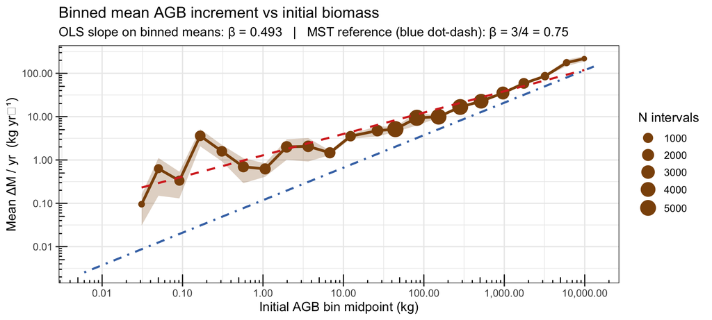

```r
bin_agb <- pos_agb |>
  filter(AGB_start > 0) |>
  mutate(AGB_bin = cut(log10(AGB_start),
                       breaks = seq(log10(0.01), log10(30000), length.out = 25),
                       include.lowest = TRUE)) |>
  filter(!is.na(AGB_bin)) |>
  group_by(AGB_bin) |>
  summarise(
    n          = n(),
    AGB_mid    = 10^mean(log10(AGB_start)),
    mean_dM    = mean(AGB_inc_kg_yr),
    median_dM  = median(AGB_inc_kg_yr),
    se_dM      = sd(AGB_inc_kg_yr) / sqrt(n()),
    .groups    = "drop"
  ) |>
  filter(n >= 10, mean_dM > 0)

m_bin_agb <- lm(log(mean_dM) ~ log(AGB_mid), data = bin_agb)
beta_bin_agb <- round(coef(m_bin_agb)[2], 3)

ggplot(bin_agb, aes(x = AGB_mid, y = mean_dM)) +
  geom_ribbon(aes(ymin = pmax(mean_dM - se_dM, 1e-4),
                  ymax = mean_dM + se_dM),
              fill = "#8c510a", alpha = 0.25) +
  geom_line(color = "#8c510a", linewidth = 1.3) +
  geom_point(aes(size = n), color = "#8c510a") +
  geom_smooth(method = "lm", formula = y ~ x,
              color = "#d73027", linewidth = 1, linetype = "dashed", se = FALSE) +
  geom_line(data = ref_mst_agb,
            aes(x = AGB_start, y = AGB_inc_kg_yr),
            color = "#4575b4", linewidth = 1, linetype = "dotdash",
            inherit.aes = FALSE) +
  scale_x_log10(labels = comma,
                breaks = c(0.01, 0.1, 1, 10, 100, 1000, 10000)) +
  scale_y_log10(labels = comma) +
  annotation_logticks() +
  scale_size_continuous(range = c(2, 7), name = "N intervals") +
  labs(
    x = "Initial AGB bin midpoint (kg)",
    y = "Mean \u0394M / yr  (kg yr\u207b\u00b9)",
    title = "Binned mean AGB increment vs initial biomass",
    subtitle = paste0(
      "OLS slope on binned means: \u03b2 = ", beta_bin_agb,
      "   |   MST reference (blue dot-dash): \u03b2 = 3/4 = 0.75"
    )
  )
```

# 5 Relative growth rate (RGR) vs initial DBH

RGR removes the size-dependence of absolute increment:
$$\text{RGR}_D = \frac{\ln D_2 - \ln D_1}{\Delta
t}$$

MST predicts RGR $\propto D^{-2/3}$ under the WBE pipe model.

## 5.1 Scatter + fit

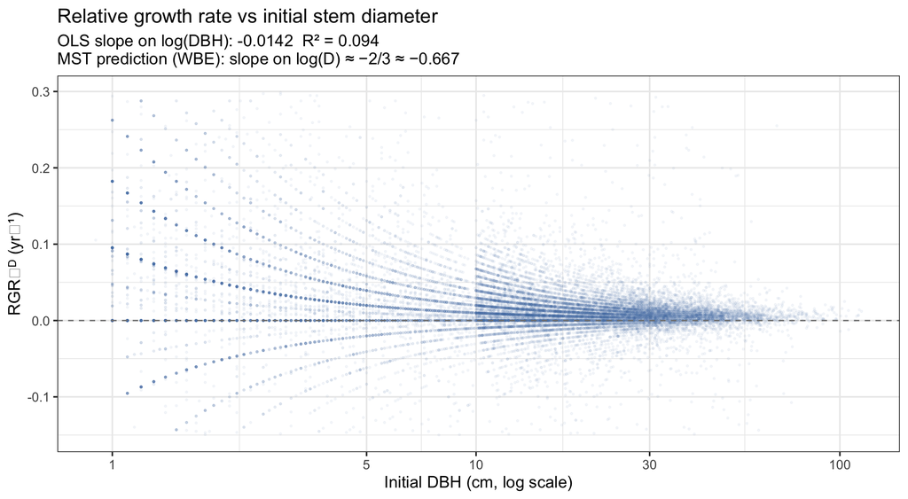

```r
rgr_dat <- annual |>
  filter(!is.na(RGR_DBH), is.finite(RGR_DBH),
         !is.na(DBH_start), DBH_start > 0,
         RGR_DBH > -0.15, RGR_DBH < 0.3)

set.seed(42)
sub_rgr <- rgr_dat |> sample_n(min(25000, n()))

m_rgr   <- lm(RGR_DBH ~ log(DBH_start), data = sub_rgr)
b_rgr   <- round(coef(m_rgr)[2], 4)
r2_rgr  <- round(summary(m_rgr)$r.squared, 3)

ggplot(sub_rgr, aes(x = DBH_start, y = RGR_DBH)) +
  geom_point(alpha = 0.05, size = 0.5, color = "#4575b4") +
  geom_smooth(method = "lm", formula = y ~ log(x),
              color = "#d73027", linewidth = 1.3, se = TRUE) +
  geom_hline(yintercept = 0, linetype = "dashed", color = "grey50") +
  scale_x_log10(labels = comma, breaks = c(1, 5, 10, 30, 100)) +
  labs(
    x = "Initial DBH (cm, log scale)",
    y = "RGR\u208d\u1d30 (yr\u207b\u00b9)",
    title = "Relative growth rate vs initial stem diameter",
    subtitle = paste0(
      "OLS slope on log(DBH): ", b_rgr, "  R\u00b2 = ", r2_rgr,
      "\nMST prediction (WBE): slope on log(D) \u2248 \u22122/3 \u2248 \u22120.667"
    )
  )
```

## 5.2 Binned median RGR

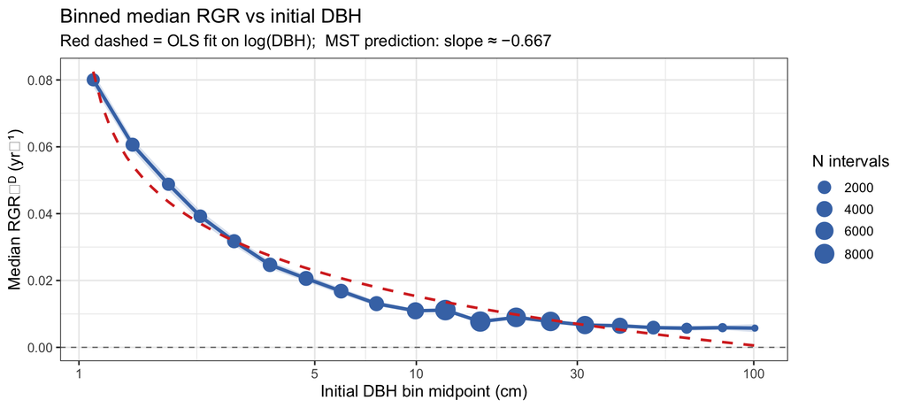

```r
bin_rgr <- rgr_dat |>
  mutate(DBH_bin = cut(log10(DBH_start),
                       breaks = seq(log10(1), log10(150), length.out = 22),
                       include.lowest = TRUE)) |>
  filter(!is.na(DBH_bin)) |>
  group_by(DBH_bin) |>
  summarise(
    n          = n(),
    DBH_mid    = 10^mean(log10(DBH_start)),
    median_RGR = median(RGR_DBH),
    mean_RGR   = mean(RGR_DBH),
    se_RGR     = sd(RGR_DBH) / sqrt(n()),
    .groups    = "drop"
  ) |>
  filter(n >= 20)

ggplot(bin_rgr, aes(x = DBH_mid, y = median_RGR)) +
  geom_ribbon(aes(ymin = median_RGR - se_RGR, ymax = median_RGR + se_RGR),
              fill = "#4575b4", alpha = 0.2) +
  geom_line(color = "#4575b4", linewidth = 1.3) +
  geom_point(aes(size = n), color = "#4575b4") +
  geom_smooth(method = "lm", formula = y ~ log(x),
              color = "#d73027", linewidth = 1, linetype = "dashed", se = FALSE) +
  geom_hline(yintercept = 0, linetype = "dashed", color = "grey50") +
  scale_x_log10(labels = comma, breaks = c(1, 5, 10, 30, 100)) +
  scale_size_continuous(range = c(2, 7), name = "N intervals") +
  labs(
    x = "Initial DBH bin midpoint (cm)",
    y = "Median RGR\u208d\u1d30 (yr\u207b\u00b9)",
    title = "Binned median RGR vs initial DBH",
    subtitle = "Red dashed = OLS fit on log(DBH);  MST prediction: slope \u2248 \u22120.667"
  )
```

# 6 Per-site allometric exponents

How does the scaling exponent of $\Delta D \sim D^{\beta}$ vary across NEON sites?

```r
site_exp <- pos_dbh |>
  group_by(siteID) |>
  filter(n() >= 50) |>
  summarise(
    n      = n(),
    beta   = round(coef(lm(log(DBH_inc_cm_yr) ~ log(DBH_start)))[2], 3),
    R2     = round(summary(lm(log(DBH_inc_cm_yr) ~ log(DBH_start)))$r.squared, 3),
    intercept = round(coef(lm(log(DBH_inc_cm_yr) ~ log(DBH_start)))[1], 3),
    med_inc   = round(median(DBH_inc_cm_yr), 3),
    .groups = "drop"
  ) |>
  arrange(desc(beta))

kable(site_exp,
      col.names = c("Site","N","\u03b2 (slope)","R\u00b2","Intercept (log)",
                    "Median \u0394D (cm/yr)"),
      caption   = paste0(
        "OLS log-log \u0394D ~ D\u1da6 exponents per NEON site. ",
        "MST prediction: \u03b2 = 1/3. ",
        "\u26a0 OLS underestimates slope; SMA preferred for formal inference."))
```

OLS log-log ΔD ~ Dᶦ exponents per NEON site. MST prediction: β = 1/3. ⚠ OLS underestimates slope; SMA preferred for formal inference.

| Site | N | β (slope) | R² | Intercept (log) | Median ΔD (cm/yr) |
| --- | --- | --- | --- | --- | --- |
| LENO | 1845 | 0.460 | 0.233 | -2.292 | 0.300 |
| BLAN | 738 | 0.451 | 0.209 | -2.078 | 0.325 |
| KONZ | 77 | 0.429 | 0.164 | -1.519 | 0.500 |
| DELA | 3422 | 0.378 | 0.146 | -2.024 | 0.300 |
| SCBI | 1596 | 0.371 | 0.153 | -2.195 | 0.300 |
| SERC | 3338 | 0.350 | 0.172 | -2.331 | 0.200 |
| ORNL | 2986 | 0.341 | 0.065 | -2.537 | 0.200 |
| UNDE | 3234 | 0.327 | 0.094 | -2.267 | 0.250 |
| STEI | 2974 | 0.302 | 0.097 | -1.837 | 0.300 |
| GUAN | 1001 | 0.278 | 0.028 | -2.460 | 0.150 |
| TALL | 2097 | 0.277 | 0.052 | -1.887 | 0.300 |
| CLBJ | 1291 | 0.262 | 0.076 | -1.637 | 0.400 |
| UKFS | 2531 | 0.237 | 0.042 | -1.694 | 0.350 |
| HARV | 5100 | 0.211 | 0.064 | -2.119 | 0.200 |
| YELL | 486 | 0.208 | 0.085 | -1.436 | 0.400 |
| BART | 5419 | 0.200 | 0.060 | -2.033 | 0.200 |
| JERC | 945 | 0.196 | 0.058 | -1.560 | 0.350 |
| GRSM | 2861 | 0.195 | 0.040 | -1.845 | 0.300 |
| MLBS | 2688 | 0.180 | 0.024 | -2.061 | 0.200 |
| RMNP | 1610 | 0.136 | 0.013 | -1.906 | 0.200 |
| TREE | 3302 | 0.129 | 0.022 | -1.604 | 0.300 |
| OSBS | 1616 | 0.096 | 0.007 | -1.350 | 0.350 |

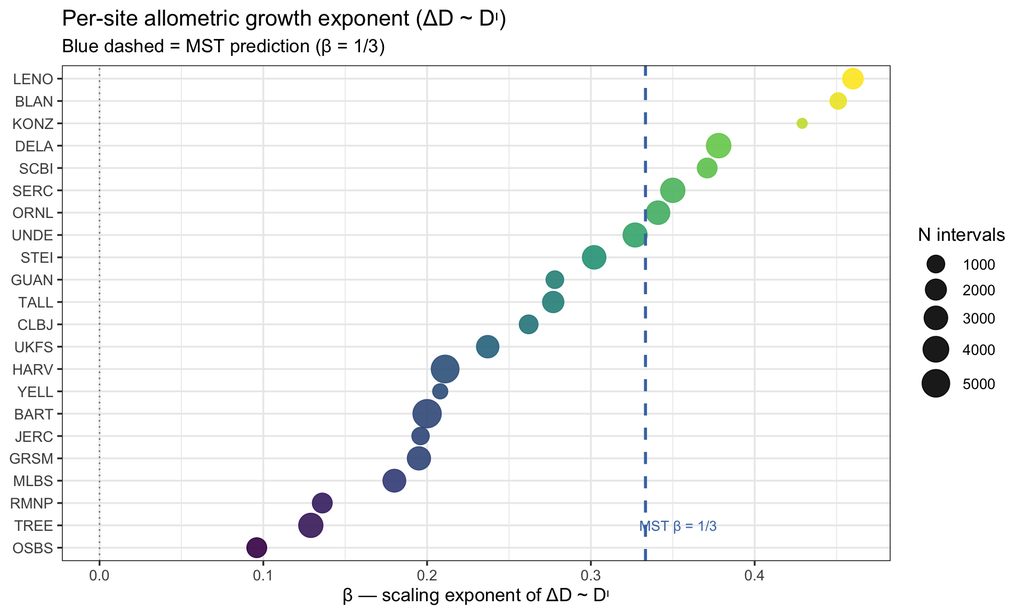

```r
ggplot(site_exp, aes(x = reorder(siteID, beta), y = beta, color = beta)) +
  geom_point(aes(size = n), alpha = 0.9) +
  geom_errorbar(aes(ymin = beta, ymax = beta), width = 0, linewidth = 0) +
  geom_hline(yintercept = 1/3, linetype = "dashed", color = "#4575b4",
             linewidth = 1) +
  geom_hline(yintercept = 0, linetype = "dotted", color = "grey50") +
  annotate("text", x = 2, y = 1/3 + 0.02, label = "MST \u03b2 = 1/3",
           color = "#4575b4", size = 3.5) +
  scale_color_viridis_c(option = "D", guide = "none") +
  scale_size_continuous(range = c(3, 9), name = "N intervals") +
  coord_flip() +
  labs(
    x = NULL,
    y = "\u03b2 — scaling exponent of \u0394D ~ D\u1da6",
    title = "Per-site allometric growth exponent (\u0394D ~ D\u1da6)",
    subtitle = "Blue dashed = MST prediction (\u03b2 = 1/3)"
  )
```